# Midterm Project (Rough Draft)

Hansol Kim

## Overview

Original visualization:

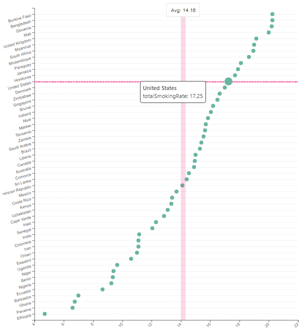

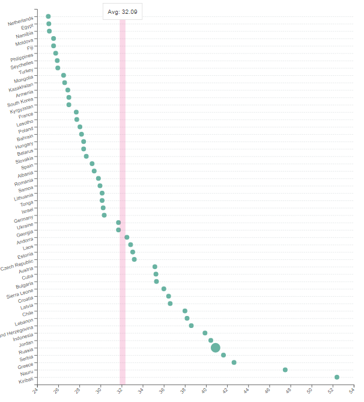

Claim:

> The tobacco prevalence is affected by several factors. Properity is the first of these. Wealthier countries tend to smoke more. Certain religions such as Christianity and Judaism, are anti-tobacco.

## Design

It seems like a scatter plot was used in this original visualization. Since there are over a hundred countries listed in the data set, the author may have thought the scatter plot is the best plot to represent numerous rows. The author could have labeled the country names on the x-axis, but to make it a easier to view, I think he or she labeled the country names on the y-axis and the total smoking rate on the x-axis. The dots or the points are presented in green and there are no specific size is assigned. When the viewer moves the cursor on a certain point, the total rate of that country shows up. The author also used lines in the background so that it is easy to follow which point belongs to which country. The author used all the country names in the plot. I think there could be an adjustment here. Although these country names are appropriate variables to use, there are too many to of them to show in one plot. Thus, I think we can reduce some countries, for example, filtering only the OECD countries. The claim is clear and straightforward, but the visualization is not very effective. We can barely find any association between its claim and its visualization. For example, the original visualization does not really show how economic status or the religion of a country has affect on the smoking rate.

## Data

### Data Overview

I was able to find the original data, and found couple other data sets to join gdp and religion into the original data set. The data sets of smoking rate came from the website which can be downloaded as a csv file: https://worldpopulationreview.com/country-rankings/smoking-rates-by-country This website allows anyone to download the data because this website provides open databases of various research on the world population. The data seems to be a single file with no aggregation with other files. Furthermore, no personal information was stored in the data set. We may need to include all the data. There should not be any biased action during the data collection process. After all the data is collected, then we can manipulate the data. For example, using left_join or inner_join to filter any unmatching or missing data.

### Data Details

```r
# your code to load the data here
smoking <- read_csv('csvData.csv')
gdp <- read_csv('world_gdp.csv')
religion <- read_csv('world_religion.csv')
```

### Wrangling

I will need to join religion and smoking data sets first because they have the full names of the countries. Then I will need to use gapminder::country_codes to add full names to gdp data set which only has country abbreviations. Finally, I will join two dat sets that will have both full names of countries and abbreviations, gdp, and religion.

```r
## Rename columns and select useful columns of the gdp data set

gdp <- rename(gdp, gdp = Value, country = LOCATION)
gdp <- gdp %>%
  select(country, TIME, gdp)
```

```r
## Join smoking and religion data sets.

smoking_new <- smoking %>%
  select(country, rateBoth)

smoking_religion <- religion %>%
  left_join(smoking_new) %>%
  drop_na()
# make country names same as the ones in gapminder::country_codes

smoking_religion[smoking_religion == "South Korea"] <- "Korea, Rep."
smoking_religion[smoking_religion == "North Korea"] <- "Korea, Dem. Rep."
```

```r
## Join country abbreviations names to the gdp data set using gapminder::country_codes

#View(gapminder::country_codes)
gapminder <- gapminder::country_codes %>%
  select(country, iso_alpha)

smoking_religion <- left_join(smoking_religion, gapminder,
                               by = c("country" = "country")) %>% drop_na()
```

```r
## Finally, combine all three data sets into a one data set called semi_final.

semi_final <- left_join(smoking_religion, gdp, by = c("iso_alpha" = "country"))
```

```r
## Filter countries by the most recent year (2020).

final <- semi_final %>%
  group_by(country) %>%
  filter(TIME > 2019) %>%
  drop_na()
# final <- final %>%
#   group_by(country) %>%
#   arrange(TIME) %>%
#   slice_tail(n = 1 ) %>%
#   drop_na()
```

## Replication

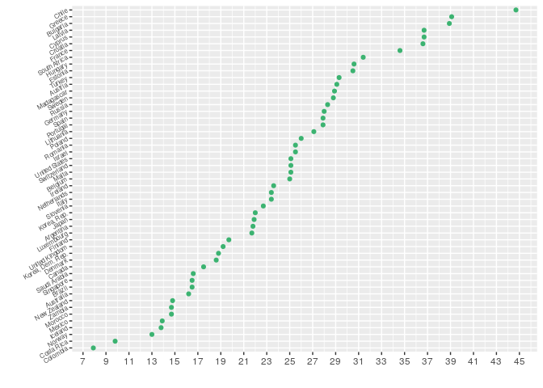

```r
#smoking <- left_join(smoking, gapminder::country_codes, by = c("country" = "iso_alpha"))

rep <- semi_final %>%
  filter(TIME == "2018")

rep %>%
  mutate(country = fct_reorder(country, rateBoth)) %>%
  ggplot( aes(x=country, y=rateBoth)) +
  geom_point(color ="#3CB371", width=0.5) +
  scale_y_continuous(breaks = seq(form = 4, to = 46, by = 2)) +
  coord_flip() +
  labs(x = " ",
       y = " ") +
  theme(axis.text.y = element_text(angle = 30, size = 6))
```

Making the y label (smoking rate) break by 2 units was difficult, but I was able to fix it in the end. The original smoking data set only had country names, male, female, and the average smoking rate of both gender. The original data set was good enough to make replication, but adding different sets of data like religion and gdp was not easy. Especially the some data set had full names of countries and the other data set only had country abbreviations. There are still a few things need to be done in the replication. For example, there are more than a hundred countries labeled in the original visualization. However, I am not completely sure how the author managed to put data for all countries in a single year without overlapping with other years because there are many missing data in each year.

## Alternatives

### Design

In the original visualization, scatter plot was used to represent average smoking rate of each countries with a preset color. An alternative choice would be using the same type of plot but with various colors and additional data. In order to support the original claim, we need to make the plot that does represents the claim. For now, it is hard to see the claim’s support in the original visualization. The original claim states that wealthier countries tend to smoke more. We could use gdp to see how gdp relates to tobacco use in each country. The original claim also states that religion affects smoking rate of a country. We can use religion data to see the relationship. Furthermore, there are too many countries labeled in a single plot. We could reduce the number of countries so that the plot does not need to be divided into two plots.